# Model Selection Assignment

Jake Barrett

10/2/2021

```r
library(ggplot2)
library(dplyr)
library(lme4)
library(lmerTest)
library(ggfortify)
library(MuMIn)
library(asbio)
library(GGally)
library(performance)
library(patchwork)
```

$~$

## Example 1: HML Growth

$~$

I wanted to re-visit the high mountain lake dataset from Symons et al. 2019 in order to try and find a model that’s able to explain differences in growth rates for each sampled trout during their first year of life. Such a model could potentially inform managers on which lakes to prioritize for stocking.

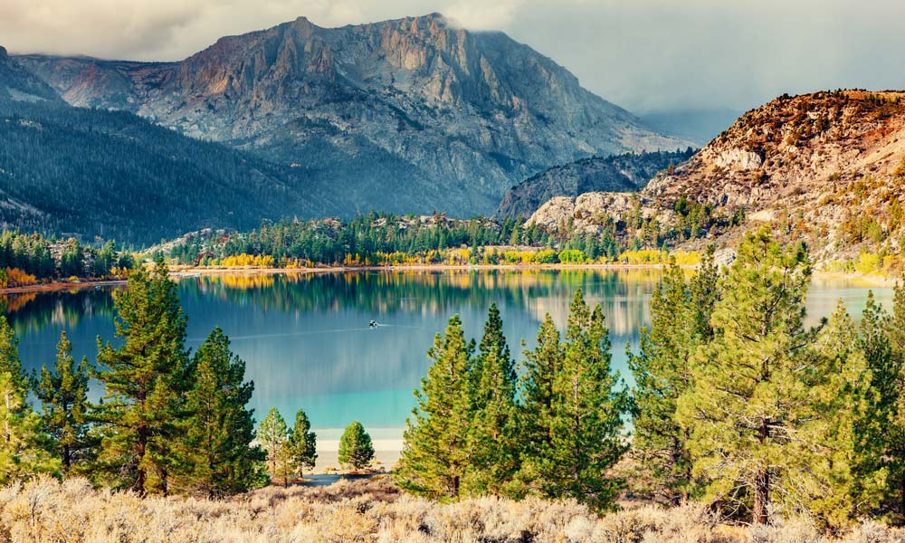

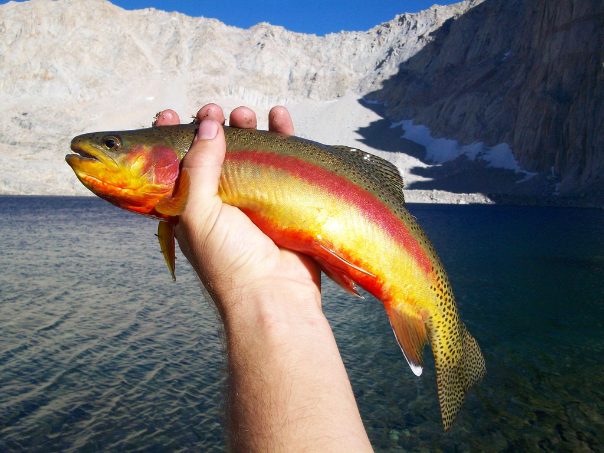

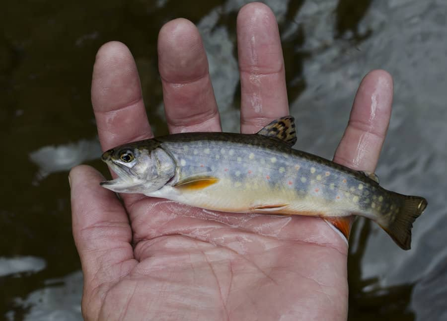

$~$

1.1 Data visualization and colinearity check

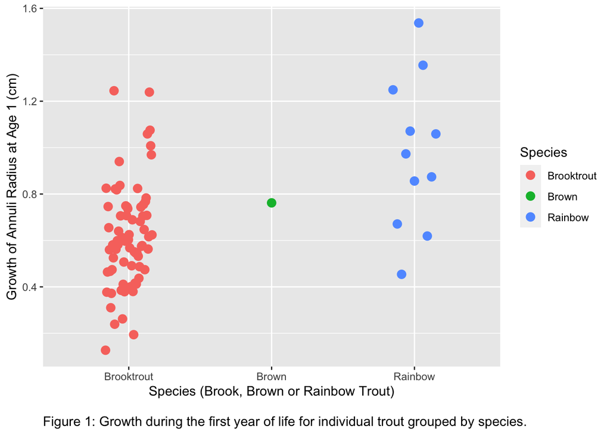

```r
fish <- read.csv("data/HMLgrowth(edited).csv") #Maybe have to remove fish with n.a. for growth?

ggplot(fish, aes(Species, grow.age.1, colour = Species)) +
  geom_point(size=3, position = position_dodge2(width=.33, preserve = "total"))+
  xlab ("Species (Brook, Brown or Rainbow Trout)") +
  ylab ("Growth of Annuli Radius at Age 1 (cm)") +
  labs(caption="Figure 1: Growth during the first year of life for individual trout grouped by species.") +
  theme(plot.caption=element_text(size=11, hjust=0, margin=margin(15,0,0,0)))
```

I’m mostly interested in the powers of surface temperature, dissolved organic carbon, dissolved nitrogen, and the isotopic signatures of carbon and nitrogen in sampled fish tissues to explain first-year growth. The authors had clear biological reasons for considering these as important parameters.

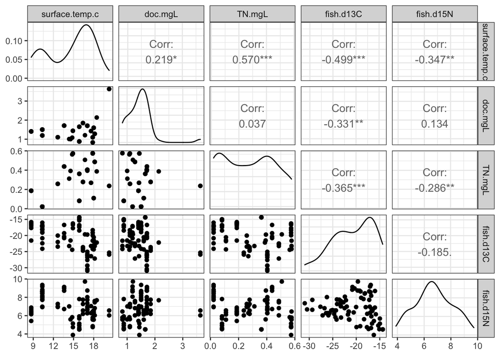

```r
ggpairs(fish, columns = 4:8) + theme_bw()
```

There are some fairly highly colinear relationships here (such as 0.570 between total nitrogen and surface temp), but I decided to wait to test for multicolinearity before I threw out any predictor variables.

$~$

1.2 Model formation and multicolinearity check

I formulated my model to explain the first-year growth with average annual surface temp (Celsius), concentration of dissolved carbon (mg/L), total nitrogen (mg/L), 13C and 15N isotopic tissue signatures as explanatory variables.

```r
fish_wash1 <- lm(grow.age.1 ~ surface.temp.c + doc.mgL + TN.mgL + fish.d13C + fish.d15N, data = fish)
anova(fish_wash1)
```

```
## Analysis of Variance Table
##
## Response: grow.age.1
##                Df Sum Sq Mean Sq F value   Pr(>F)
## surface.temp.c  1 0.5251 0.52507  8.1390 0.005544 **
## doc.mgL         1 0.0533 0.05331  0.8264 0.366118
## TN.mgL          1 0.1539 0.15388  2.3852 0.126536
## fish.d13C       1 0.0084 0.00842  0.1305 0.718882
## fish.d15N       1 0.0162 0.01620  0.2511 0.617704
## Residuals      78 5.0320 0.06451
## ---
## Signif. codes:  0 '***' 0.001 '**' 0.01 '*' 0.05 '.' 0.1 ' ' 1
```

Based on the above ANOVA table we might expect suface temp and total nitrogen to be fairly important parameters.

```r
performance::check_collinearity(fish_wash1)
```

```
## # Check for Multicollinearity
##
## Low Correlation
##
##       Parameter  VIF Increased SE
##  surface.temp.c 2.13         1.46
##         doc.mgL 1.17         1.08
##          TN.mgL 1.58         1.26
##       fish.d13C 1.78         1.34
##       fish.d15N 1.48         1.22
```

All IVF values below 5, no multicolinearity detected - we can keep our parameters for now.

$~$

1.3 Dredging

```r
options(na.action = "na.fail")
dredge_fish <- dredge(fish_wash1)
```

```
## Fixed term is "(Intercept)"
```

```r
dredge_fish
```

```
## Global model call: lm(formula = grow.age.1 ~ surface.temp.c + doc.mgL + TN.mgL +
##     fish.d13C + fish.d15N, data = fish)
## ---
## Model selection table
##     (Int)   doc.mgL    fsh.d13   fsh.d15 srf.tmp.c TN.mgL df logLik AICc delta
## 17 0.5446                                          0.4384  3 -2.503 11.3  0.00
## 25 0.3769                                  0.01422 0.2937  4 -1.454 11.4  0.11
## 9  0.3200                                  0.02360         3 -2.852 12.0  0.70
## 26 0.4211 -0.046110                        0.01605 0.2792  5 -1.166 13.1  1.79
## 27 0.4277            0.0042230             0.01650 0.3050  5 -1.292 13.4  2.05
## 10 0.3778 -0.056670                        0.02528         4 -2.425 13.4  2.05
## 18 0.5771 -0.022760                                0.4404  4 -2.430 13.4  2.06
## 21 0.5758                      -0.004276           0.4295  4 -2.482 13.5  2.16
## 19 0.5412           -0.0001856                     0.4369  4 -2.502 13.5  2.21
## 29 0.3524                       0.002854   0.01454 0.2964  5 -1.445 13.7  2.35
```

[output cut: 56 more lines]

Arbitrarily sub-setting for <2 AIC will give us 4 top models, but sub-setting for <2.5 delta AIC will give us 10 models w/ 6 that are nearly as important as our 4th most important.

So, let’s stick with within 2.5 AIC for now:

```r
subset(dredge_fish, delta <2.5)
```

```
## Global model call: lm(formula = grow.age.1 ~ surface.temp.c + doc.mgL + TN.mgL +
##     fish.d13C + fish.d15N, data = fish)
## ---
## Model selection table
##     (Int)  doc.mgL    fsh.d13   fsh.d15 srf.tmp.c TN.mgL df logLik AICc delta
## 17 0.5446                                         0.4384  3 -2.503 11.3  0.00
## 25 0.3769                                 0.01422 0.2937  4 -1.454 11.4  0.11
## 9  0.3200                                 0.02360         3 -2.852 12.0  0.70
## 26 0.4211 -0.04611                        0.01605 0.2792  5 -1.166 13.1  1.79
## 27 0.4277           0.0042230             0.01650 0.3050  5 -1.292 13.4  2.05
## 10 0.3778 -0.05667                        0.02528         4 -2.425 13.4  2.05
## 18 0.5771 -0.02276                                0.4404  4 -2.430 13.4  2.06
## 21 0.5758                     -0.004276           0.4295  4 -2.482 13.5  2.16
## 19 0.5412          -0.0001856                     0.4369  4 -2.502 13.5  2.21
## 29 0.3524                      0.002854   0.01454 0.2964  5 -1.445 13.7  2.35
##    weight
## 17  0.196
## 25  0.185
## 9   0.138
## 26  0.080
## 27  0.070
## 10  0.070
## 18  0.070
## 21  0.066
## 19  0.065
## 29  0.060
## Models ranked by AICc(x)
```

$~$

1.4 Parameter importance and model averaging

Next, let’s look at the importance of the included parameters:

```r
importance(dredge_fish)
```

```
##                      TN.mgL surface.temp.c doc.mgL fish.d13C fish.d15N
## Sum of weights:      0.71   0.63           0.29    0.26      0.25
## N containing models:   16     16             16      16        16
```

Strong support for including total nitrogen and suface temperature in an explanation of first-year growth, with much lower support for the other 3 parameters.

I decided to average my top 10 models as a sort of compromise between including all possible models and just those within the arbitrarily narrow 2 AIC score range.

```r
fish_topmods <- subset(dredge_fish, delta <2.5)

model.avg(fish_topmods, revised.var = TRUE)
```

```
##
## Call:
## model.avg(object = fish_topmods, revised.var = TRUE)
##
## Component models:
## '5'   '45'  '4'   '145' '245' '14'  '15'  '35'  '25'  '345'
##
## Coefficients:
##        (Intercept)    TN.mgL surface.temp.c      doc.mgL    fish.d13C
## full     0.4453423 0.2892124     0.01097599 -0.009240794 0.0002845788
## subset   0.4453423 0.3652014     0.01818777 -0.042067344 0.0021055800
##            fish.d15N
## full   -0.0001113611
## subset -0.0008799448
```

```r
summary(model.avg(fish_topmods))
```

```
##
## Call:
## model.avg(object = fish_topmods)
##
## Component model call:
## lm(formula = grow.age.1 ~ <10 unique rhs>, data = fish)
##
## Component models:
##     df logLik  AICc delta weight
## 5    3  -2.50 11.31  0.00   0.20
## 45   4  -1.45 11.41  0.11   0.19
## 4    3  -2.85 12.00  0.70   0.14
## 145  5  -1.17 13.10  1.79   0.08
## 245  5  -1.29 13.35  2.05   0.07
## 14   4  -2.42 13.36  2.05   0.07
## 15   4  -2.43 13.37  2.06   0.07
## 35   4  -2.48 13.47  2.16   0.07
## 25   4  -2.50 13.51  2.21   0.06
## 345  5  -1.45 13.66  2.35   0.06
##
## Term codes:
##        doc.mgL      fish.d13C      fish.d15N surface.temp.c         TN.mgL
##              1              2              3              4              5
##
## Model-averaged coefficients:
## (full average)
##                  Estimate Std. Error Adjusted SE z value Pr(>|z|)
## (Intercept)     0.4453423  0.1603269   0.1619343   2.750  0.00596 **
## TN.mgL          0.2892124  0.2182070   0.2197106   1.316  0.18806
## surface.temp.c  0.0109760  0.0121100   0.0121802   0.901  0.36752
## doc.mgL        -0.0092408  0.0343888   0.0347605   0.266  0.79036
## fish.d13C       0.0002846  0.0029114   0.0029497   0.096  0.92314
## fish.d15N      -0.0001114  0.0077162   0.0078306   0.014  0.98865
##
## (conditional average)
##                  Estimate Std. Error Adjusted SE z value Pr(>|z|)
## (Intercept)     0.4453423  0.1603269   0.1619343   2.750  0.00596 **
## TN.mgL          0.3652014  0.1799261   0.1822220   2.004  0.04505 *
## surface.temp.c  0.0181878  0.0105756   0.0107084   1.698  0.08942 .
## doc.mgL        -0.0420673  0.0632665   0.0641844   0.655  0.51220
## fish.d13C       0.0021056  0.0076733   0.0077809   0.271  0.78669
## fish.d15N      -0.0008799  0.0216746   0.0219964   0.040  0.96809
## ---
## Signif. codes:  0 '***' 0.001 '**' 0.01 '*' 0.05 '.' 0.1 ' ' 1
```

**Can you do this? Can you choose to model average over a select number of models?**

$~$

1.5 AIC table

Now for a “publishable” table:

```r
fish.out.put <- model.sel(fish_topmods)
fish.out.put
```

```
## Global model call: lm(formula = grow.age.1 ~ surface.temp.c + doc.mgL + TN.mgL +
##     fish.d13C + fish.d15N, data = fish)
## ---
## Model selection table
##     (Int)  doc.mgL    fsh.d13   fsh.d15 srf.tmp.c TN.mgL df logLik AICc delta
## 17 0.5446                                         0.4384  3 -2.503 11.3  0.00
## 25 0.3769                                 0.01422 0.2937  4 -1.454 11.4  0.11
## 9  0.3200                                 0.02360         3 -2.852 12.0  0.70
## 26 0.4211 -0.04611                        0.01605 0.2792  5 -1.166 13.1  1.79
## 27 0.4277           0.0042230             0.01650 0.3050  5 -1.292 13.4  2.05
## 10 0.3778 -0.05667                        0.02528         4 -2.425 13.4  2.05
## 18 0.5771 -0.02276                                0.4404  4 -2.430 13.4  2.06
## 21 0.5758                     -0.004276           0.4295  4 -2.482 13.5  2.16
## 19 0.5412          -0.0001856                     0.4369  4 -2.502 13.5  2.21
## 29 0.3524                      0.002854   0.01454 0.2964  5 -1.445 13.7  2.35
##    weight
## 17  0.196
## 25  0.185
## 9   0.138
## 26  0.080
## 27  0.070
## 10  0.070
## 18  0.070
## 21  0.066
## 19  0.065
## 29  0.060
## Models ranked by AICc(x)
```

```r
str(fish.out.put)
```

[output not shown]

[output cut: 81 more lines]

[output not shown]

```r
fish.sel.table<-as.data.frame(fish.out.put)[7:11]
fish.sel.table
```

```
##    df    logLik     AICc     delta     weight
## 17  3 -2.502837 11.30567 0.0000000 0.19555372
## 25  4 -1.454247 11.41482 0.1091486 0.18516750
## 9   3 -2.852122 12.00424 0.6985699 0.13790294
## 26  5 -1.165539 13.10031 1.7946345 0.07971979
## 27  5 -1.292098 13.35343 2.0477509 0.07024293
## 10  4 -2.424570 13.35547 2.0497932 0.07017124
## 18  4 -2.430223 13.36678 2.0611000 0.06977565
## 21  4 -2.481661 13.46965 2.1639760 0.06627728
## 19  4 -2.502481 13.51129 2.2056163 0.06491164
## 29  5 -1.445101 13.65943 2.3537584 0.06027732
```

```r
#rounding
fish.sel.table[,2:3]<- round(fish.sel.table[,2:3],2)
fish.sel.table[,4:5]<- round(fish.sel.table[,4:5],3)
fish.sel.table
```

```
##    df logLik  AICc delta weight
## 17  3  -2.50 11.31 0.000  0.196
## 25  4  -1.45 11.41 0.109  0.185
## 9   3  -2.85 12.00 0.699  0.138
## 26  5  -1.17 13.10 1.795  0.080
## 27  5  -1.29 13.35 2.048  0.070
## 10  4  -2.42 13.36 2.050  0.070
## 18  4  -2.43 13.37 2.061  0.070
## 21  4  -2.48 13.47 2.164  0.066
## 19  4  -2.50 13.51 2.206  0.065
## 29  5  -1.45 13.66 2.354  0.060
```

```r
#rename number of parameters
names(fish.sel.table)[1] = "K"

#put model names in a column
fish.sel.table$Model<-rownames(fish.sel.table)

#replace model names with their formulas #NOT SURE WHY THIS ISN'T WORKING
#for(i in 1:nrow(fish.sel.table)) fish.sel.table$Model[i] <- #as.character(formula(paste(fish.sel.table$Model[i])))[3]

#Arrange columns
fish.sel.table<-fish.sel.table[,c(6,1,2,3,4,5)]

fish.sel.table
```

```
##    Model K logLik  AICc delta weight
## 17    17 3  -2.50 11.31 0.000  0.196
## 25    25 4  -1.45 11.41 0.109  0.185
## 9      9 3  -2.85 12.00 0.699  0.138
## 26    26 5  -1.17 13.10 1.795  0.080
## 27    27 5  -1.29 13.35 2.048  0.070
## 10    10 4  -2.42 13.36 2.050  0.070
## 18    18 4  -2.43 13.37 2.061  0.070
## 21    21 4  -2.48 13.47 2.164  0.066
## 19    19 4  -2.50 13.51 2.206  0.065
## 29    29 5  -1.45 13.66 2.354  0.060
```

$~$

1.6 Parameter figures

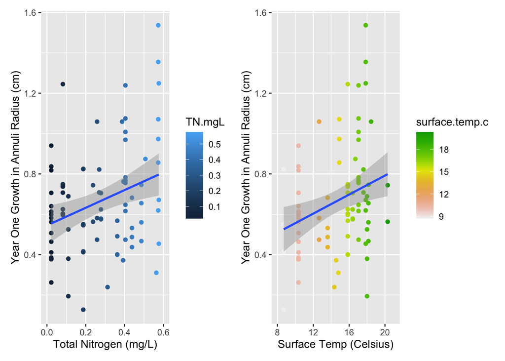

```r
p1 <- ggplot(fish, aes(TN.mgL, grow.age.1, colour = TN.mgL)) +
  geom_point() +
  geom_smooth(method="lm") +
  scale_x_continuous(limits = c(0, 0.6)) +
  xlab ("Total Nitrogen (mg/L)") +
  ylab ("Year One Growth in Annuli Radius (cm)")

p2 <- ggplot(fish, aes(surface.temp.c, grow.age.1, colour = surface.temp.c)) +
  geom_point() +
  geom_smooth(method="lm") +
  scale_colour_gradientn(colours = terrain.colors(10, rev=TRUE)) +
  scale_x_continuous(limits = c(8, 21)) +
  xlab ("Surface Temp (Celsius)") +
  ylab ("Year One Growth in Annuli Radius (cm)")

p1+p2
```

$~$

## Example 2:

$~$

For my second example, I used data from Marvalhas and Vasconcelos 2019 looking at multiple environmental factors influencing ant diversity in the Brazilian Cerrado, a Neotropical savanna region.

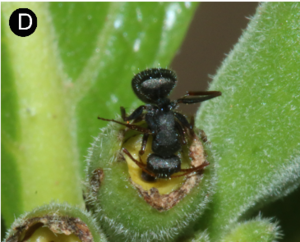

Left: *Camponotus crassus* $~$

2.1 Colinearity check

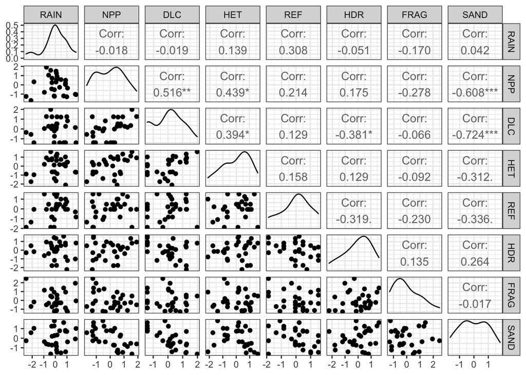

```r
ant <- read.csv("data/ant_diversity.csv")

ggpairs(ant, columns = 14:21) + theme_bw()
```

$~$

Again here, there are some *VERY* highly colinear relationships (see DLC and SAND, -0.724). But I wanted to wait to test for multicolinearity before throwing any variables out.

$~$

SAND is fairly colinear with DLC (-0.724), NPP (-0.608), and DLC and NPP are fairly colinear (0.516). Everything else looks **RELATIVELY** OK.

$~$

2.2 Model formation and multicolinearity check

```r
ant_wash1 <- lm(RSR_SS3 ~ RAIN + NPP + HDR + REF + HET + DLC + SAND + FRAG, data=ant)
anova(ant_wash1)
```

```
## Analysis of Variance Table
##
## Response: RSR_SS3
##           Df  Sum Sq Mean Sq F value    Pr(>F)
## RAIN       1  0.2835  0.2835  0.4523 0.5089347
## NPP        1 10.7500 10.7500 17.1505 0.0005055 ***
## HDR        1  1.3594  1.3594  2.1688 0.1563971
## REF        1  0.9778  0.9778  1.5600 0.2260893
## HET        1  0.0503  0.0503  0.0803 0.7797734
## DLC        1  0.0254  0.0254  0.0405 0.8424938
## SAND       1  0.1488  0.1488  0.2374 0.6313684
## FRAG       1  1.8685  1.8685  2.9810 0.0996624 .
## Residuals 20 12.5361  0.6268
## ---
## Signif. codes:  0 '***' 0.001 '**' 0.01 '*' 0.05 '.' 0.1 ' ' 1
```

From the above ANOVA table, we might expect NPP (net primary productivity) and FRAG (the proportion of coarse rock fragments) to be the most important parameters.

```r
performance::check_collinearity(ant_wash1)
```

```
## # Check for Multicollinearity
##
## Low Correlation
##
##  Parameter  VIF Increased SE
##       RAIN 1.18         1.09
##        NPP 2.93         1.71
##        HDR 2.19         1.48
##        REF 1.63         1.28
##        HET 1.45         1.21
##        DLC 3.21         1.79
##       SAND 3.22         1.79
##       FRAG 1.39         1.18
```

All VIF values less than 5, so don’t need to throw out any variables just yet!

$~$

2.3 Dredging and subsetting

```r
options(na.action = "na.fail")
dredge_ant<-dredge(ant_wash1)
```

```
## Fixed term is "(Intercept)"
```

```r
dredge_ant
```

```
## Global model call: lm(formula = RSR_SS3 ~ RAIN + NPP + HDR + REF + HET + DLC + SAND +
##     FRAG, data = ant)
## ---
## Model selection table
##        (Intrc)      DLC    FRAG       HDR        HET    NPP      RAIN       REF
## 19  -4.362e-11          -0.2693                      0.5429
## 17  -1.318e-11                                       0.6177
## 21  -1.180e-11                  -0.229000            0.6577
## 147 -8.014e-11          -0.3192                      0.3782
## 23  -3.836e-11          -0.2326 -0.185100            0.5854
## 20  -4.912e-11  0.20230 -0.2862                      0.4339
## 131 -1.284e-10          -0.4282
## 18  -1.625e-11  0.17230                              0.5288
## 83  -4.147e-11          -0.2884                      0.5596           -0.103000
## 211 -8.740e-11          -0.3692                      0.3582           -0.187400
```

[output cut: 504 more lines]

There are 6 models that are within 2 AIC of each other. Let’s subset those.

```r
subset(dredge_ant, delta <2)
```

```
## Global model call: lm(formula = RSR_SS3 ~ RAIN + NPP + HDR + REF + HET + DLC + SAND +
##     FRAG, data = ant)
## ---
## Model selection table
##        (Intrc)    DLC    FRAG     HDR    NPP    SAND df  logLik AICc delta
## 19  -4.362e-11        -0.2693         0.5429          4 -32.011 73.7  0.00
## 17  -1.318e-11                        0.6177          3 -33.672 74.3  0.62
## 21  -1.180e-11                -0.2290 0.6577          4 -32.428 74.5  0.83
## 147 -8.014e-11        -0.3192         0.3782 -0.2482  5 -31.017 74.6  0.95
## 23  -3.836e-11        -0.2326 -0.1851 0.5854          5 -31.145 74.9  1.21
## 20  -4.912e-11 0.2023 -0.2862         0.4339          5 -31.206 75.0  1.33
##     weight
## 19   0.245
## 17   0.180
## 21   0.162
## 147  0.152
## 23   0.134
## 20   0.126
## Models ranked by AICc(x)
```

Again, 6 models of relatively equal importance.

Let’s look at the most important variables.

$~$

2.4 Parameter importance and model averaging

```r
importance(dredge_ant)
```

```
##                      NPP  FRAG SAND HDR  REF  DLC  RAIN HET
## Sum of weights:      0.86 0.61 0.34 0.33 0.27 0.25 0.21 0.18
## N containing models:  128  128  128  128  128  128  128  128
```

Strong support for NPP and FRAG, but much less for the other parameters.

I decided to average my top 6 models to get adjusted estimates for the parameter coefficients.

```r
ant_topmods <- subset(dredge_ant, delta <2)

model.avg(ant_topmods, revised.var = TRUE)
```

```
##
## Call:
## model.avg(object = ant_topmods, revised.var = TRUE)
##
## Component models:
## '24'  '4'   '34'  '245' '234' '124'
##
## Coefficients:
##          (Intercept)       FRAG       NPP         HDR        SAND        DLC
## full   -3.853149e-11 -0.1819636 0.5418531 -0.06185569 -0.03779161 0.02549909
## subset -3.853149e-11 -0.2766198 0.5418531 -0.20911560 -0.24816413 0.20229703
```

```r
summary(model.avg(ant_topmods))
```

```
##
## Call:
## model.avg(object = ant_topmods)
##
## Component model call:
## lm(formula = RSR_SS3 ~ <6 unique rhs>, data = ant)
##
## Component models:
##     df logLik  AICc delta weight
## 24   4 -32.01 73.69  0.00   0.25
## 4    3 -33.67 74.30  0.62   0.18
## 34   4 -32.43 74.52  0.83   0.16
## 245  5 -31.02 74.64  0.95   0.15
## 234  5 -31.14 74.90  1.21   0.13
## 124  5 -31.21 75.02  1.33   0.13
##
## Term codes:
##  DLC FRAG  HDR  NPP SAND
##    1    2    3    4    5
##
## Model-averaged coefficients:
## (full average)
##               Estimate Std. Error Adjusted SE z value Pr(>|z|)
## (Intercept) -3.853e-11  1.438e-01   1.509e-01   0.000  1.00000
## FRAG        -1.820e-01  1.818e-01   1.861e-01   0.978  0.32807
## NPP          5.419e-01  1.877e-01   1.947e-01   2.784  0.00538 **
## HDR         -6.186e-02  1.260e-01   1.287e-01   0.481  0.63066
## SAND        -3.779e-02  1.151e-01   1.174e-01   0.322  0.74759
## DLC          2.550e-02  9.014e-02   9.220e-02   0.277  0.78212
##
## (conditional average)
##               Estimate Std. Error Adjusted SE z value Pr(>|z|)
## (Intercept) -3.853e-11  1.438e-01   1.509e-01   0.000  1.00000
## FRAG        -2.766e-01  1.551e-01   1.626e-01   1.701  0.08890 .
## NPP          5.419e-01  1.877e-01   1.947e-01   2.784  0.00538 **
## HDR         -2.091e-01  1.513e-01   1.586e-01   1.318  0.18741
## SAND        -2.482e-01  1.864e-01   1.958e-01   1.267  0.20505
## DLC          2.023e-01  1.694e-01   1.780e-01   1.137  0.25570
## ---
## Signif. codes:  0 '***' 0.001 '**' 0.01 '*' 0.05 '.' 0.1 ' ' 1
```

$~$

2.5 AIC Table

Now for a “publishable” table:

```r
ant.out.put <- model.sel(ant_topmods)
ant.out.put
```

```
## Global model call: lm(formula = RSR_SS3 ~ RAIN + NPP + HDR + REF + HET + DLC + SAND +
##     FRAG, data = ant)
## ---
## Model selection table
##        (Intrc)    DLC    FRAG     HDR    NPP    SAND df  logLik AICc delta
## 19  -4.362e-11        -0.2693         0.5429          4 -32.011 73.7  0.00
## 17  -1.318e-11                        0.6177          3 -33.672 74.3  0.62
## 21  -1.180e-11                -0.2290 0.6577          4 -32.428 74.5  0.83
## 147 -8.014e-11        -0.3192         0.3782 -0.2482  5 -31.017 74.6  0.95
## 23  -3.836e-11        -0.2326 -0.1851 0.5854          5 -31.145 74.9  1.21
## 20  -4.912e-11 0.2023 -0.2862         0.4339          5 -31.206 75.0  1.33
##     weight
## 19   0.245
## 17   0.180
## 21   0.162
## 147  0.152
## 23   0.134
## 20   0.126
## Models ranked by AICc(x)
```

```r
str(ant.out.put)
```

[output not shown]

[output cut: 67 more lines]

[output not shown]

```r
ant.sel.table<-as.data.frame(ant.out.put)[10:14]
ant.sel.table
```

```
##     df    logLik     AICc     delta    weight
## 19   4 -32.01094 73.68854 0.0000000 0.2454406
## 17   3 -33.67198 74.30396 0.6154218 0.1804302
## 21   4 -32.42789 74.52244 0.8339019 0.1617584
## 147  5 -31.01723 74.64315 0.9546061 0.1522847
## 23   5 -31.14485 74.89840 1.2098601 0.1340382
## 20   5 -31.20632 75.02133 1.3327883 0.1260478
```

```r
#rounding
ant.sel.table[,2:3]<- round(ant.sel.table[,2:3],2)
ant.sel.table[,4:5]<- round(ant.sel.table[,4:5],3)
ant.sel.table
```

```
##     df logLik  AICc delta weight
## 19   4 -32.01 73.69 0.000  0.245
## 17   3 -33.67 74.30 0.615  0.180
## 21   4 -32.43 74.52 0.834  0.162
## 147  5 -31.02 74.64 0.955  0.152
## 23   5 -31.14 74.90 1.210  0.134
## 20   5 -31.21 75.02 1.333  0.126
```

```r
#rename number of parameters
names(ant.sel.table)[1] = "K"

#put model names in a column
ant.sel.table$Model<-rownames(ant.sel.table)

#replace model names with their formulas #NOT SURE WHY THIS ISN'T WORKING
#for(i in 1:nrow(ant.sel.table)) ant.sel.table$Model[i]<- #as.character(formula(paste(ant.sel.table$Model[i])))[3]

#Arrange columns
ant.sel.table<-ant.sel.table[,c(6,1,2,3,4,5)]

ant.sel.table
```

```
##     Model K logLik  AICc delta weight
## 19     19 4 -32.01 73.69 0.000  0.245
## 17     17 3 -33.67 74.30 0.615  0.180
## 21     21 4 -32.43 74.52 0.834  0.162
## 147   147 5 -31.02 74.64 0.955  0.152
## 23     23 5 -31.14 74.90 1.210  0.134
## 20     20 5 -31.21 75.02 1.333  0.126
```

$~$

2.6 Visualization of important parameters

And “publishable” figures for the effects of our two most important predictors:

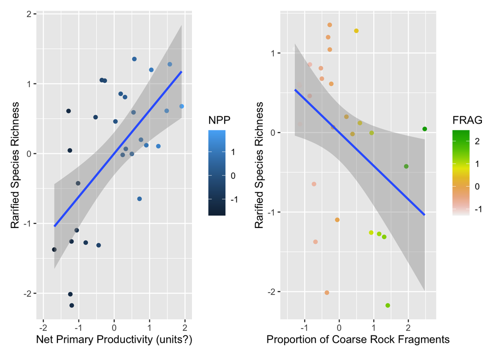

```r
p3 <- ggplot(ant, aes(NPP, RSR_SS3, colour = NPP)) +
  geom_point() +
  geom_smooth(method="lm")+
  scale_x_continuous(limits = c(-2, 2)) +
  xlab ("Net Primary Productivity (units?)") +
  ylab ("Rarified Species Richness")

p4 <- ggplot(ant, aes(FRAG, RSR_SS3, colour = FRAG)) +
  geom_point() +
  geom_smooth(method="lm") +
  scale_colour_gradientn(colours = terrain.colors(10, rev=TRUE)) +
  scale_x_continuous(limits = c(-1.5, 2.6)) +
  xlab ("Proportion of Coarse Rock Fragments") +
  ylab ("Rarified Species Richness")

p3+p4
```